# Graphing Occupancy Analysis - Combined Species

Description: This program graphs occupancy analysis results for owls of El Salvador. Plots show the posteriors of Psi and P(detection).

### Preamble

Load libraries

```r
library(knitr) # documentation-related
library(ezknitr) # documentation-related
library(devtools) # documentation-related

# analysis-related
library(ggplot2)
library(ggthemes)
library(maptools)
library(plyr)
library(rgdal)
library(raster)
library(mapproj)
library(stringr)
library(ggspatial)
```

Clear environment and set seed

*Note: for reproducibility, it is important to include these. Clearing the environment ensures that you have specified all pertinent files that need to be loaded, and setting the seed ensures that your analysis is repeatable*

```r
remove(list = ls())
set.seed(587453)
```

## Load Data

Psi Posteriors by year and route

```r
load(file = "data/plotting_data/specd_psi_posteriors_RtYr.Rdata")
load(file = "data/plotting_data/ferpy_psi_posteriors_RtYr.Rdata")
load(file = "data/plotting_data/mottd_psi_posteriors_RtYr.Rdata")
load(file = "data/plotting_data/richness_psi_posteriors_RtYr.Rdata")
```

Psi posteriors across years by species and route

```r
load(file = "data/plotting_data/specd_psi_posteriors_RtSpp.Rdata")
load(file = "data/plotting_data/ferpy_psi_posteriors_RtSpp.Rdata")
load(file = "data/plotting_data/mottd_psi_posteriors_RtSpp.Rdata")
```

Probability of detection by broadcast species and species of analysis

```r
load(file = "data/plotting_data/specd_p_detection_posteriors.Rdata")
load(file = "data/plotting_data/ferpy_p_detection_posteriors.Rdata")
load(file = "data/plotting_data/mottd_p_detection_posteriors.Rdata")
load(file = "data/plotting_data/richness_p_detection_posteriors.Rdata")
```

Species accounts

```r
load(file = "data/output_data/richness_species_accounts.Rdata")
```

## Psi = Probability of occupancy

### By Route, averages

Add in blanks for M1 for FerPy and Specd

```r
psi.means.specd <- rbind(psi.means.specd, 0)
psi.means.specd$Route[max(nrow(psi.means.specd))] <- "M1"
psi.means.specd$Region[max(nrow(psi.means.specd))] <- "Montecristo"
psi.means.specd$Species[max(nrow(psi.means.specd))] <- "Specd"

psi.means.ferpy <- rbind(psi.means.ferpy, 0)
psi.means.ferpy$Route[max(nrow(psi.means.ferpy))] <- "M1"
psi.means.ferpy$Region[max(nrow(psi.means.ferpy))] <- "Montecristo"
psi.means.ferpy$Species[max(nrow(psi.means.ferpy))] <- "FerPy"
```

Merge data

```r
psi.means <- rbind(psi.means.ferpy, psi.means.specd, psi.means.mottd)
psi.means$code <- ifelse(psi.means$Species == "FerPy", "Ferruginous Pygmy-Owl",
                         ifelse(psi.means$Species == "Mottd", "Mottled Owl", "Spectacled Owl"))
```

Last minute fix to route names

```r
table(psi.means$Route)
```

```
##
## EI1 EI2  M1  M2  N1  N2
##   3   3   3   3   3   3
```

```r
psi.means$Route <- ifelse(psi.means$Route == "EI1", "EI-1",
                          ifelse(psi.means$Route == "EI2", "EI-2",
                                 ifelse(psi.means$Route == "M1", "M-1",
                                        ifelse(psi.means$Route == "M2", "M-2",
                                               ifelse(psi.means$Route == "N1", "N-1",
                                                      "N-2")))))
```

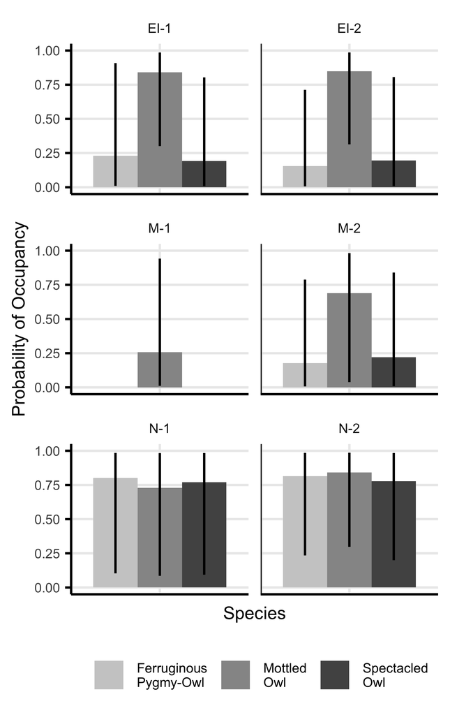

```r
ggplot(data = psi.means, aes(x = Route, y = Psi.median, group = str_wrap(code,10)))+
  geom_bar(stat = "identity", aes(fill = str_wrap(code,10)), position= position_dodge())+
  geom_linerange(aes(ymin = Psi.LL05, ymax = Psi.UL95), position = position_dodge(width = 0.9))+
  facet_wrap(~Route, nrow = 3,scales = "free_x")+
  ylim(c(0,1))+
  scale_fill_manual(values = c("#cccccc", "#969696", "#525252"))+
  theme_minimal()+
  ylab("Probability of Occupancy")+
  xlab("Species")+
  theme(legend.position = "bottom")+
  theme(legend.text=element_text(size=6),
        legend.title = element_blank(),
        axis.text.y = element_text(size=6),
        axis.text.x = element_blank(),
        axis.title.y = element_text(size=8),
        axis.title.x = element_text(size = 8),
        strip.text = element_text(size = 6),
        legend.key.size = unit(1, "line"),
        axis.line.x.bottom = element_line(colour = "black"),
        axis.line.y.left = element_line(colour = "black"),
        panel.grid.minor.y = element_blank(),
        axis.ticks.y.left = element_line(colour = "black"))+
  annotate("segment", x=-Inf, xend=Inf, y=-Inf, yend=-Inf)+
  annotate("segment", x=-Inf, xend=-Inf, y=-Inf, yend=Inf)
```

Table output for paper

```r
psi.means
```

```
##    Species Route    Psi.LL05 Psi.median  Psi.UL95       Region
## 1    FerPy  EI-1 0.009228696  0.2303874 0.9083394 El Imposible
## 2    FerPy  EI-2 0.006544099  0.1556266 0.7124247 El Imposible
## 3    FerPy   M-2 0.007199966  0.1775983 0.7883124  Montecristo
## 4    FerPy   N-1 0.103409165  0.8012297 0.9845271 Nancuchiname
## 5    FerPy   N-2 0.234369874  0.8143596 0.9848435 Nancuchiname
## 6    FerPy   M-1 0.000000000  0.0000000 0.0000000  Montecristo
## 7    Specd  EI-1 0.008414678  0.1924513 0.8034594 El Imposible
## 8    Specd  EI-2 0.008260376  0.1955225 0.8059955 El Imposible
## 9    Specd   M-2 0.008816131  0.2213357 0.8398317  Montecristo
## 10   Specd   N-1 0.093256871  0.7697026 0.9837812 Nancuchiname
## 11   Specd   N-2 0.199479607  0.7774122 0.9839668 Nancuchiname
## 12   Specd   M-1 0.000000000  0.0000000 0.0000000  Montecristo
## 13   Mottd  EI-1 0.301220498  0.8416020 0.9854987 El Imposible
## 14   Mottd  EI-2 0.313774553  0.8476592 0.9857743 El Imposible
```

[output cut: 23 more lines]

### By Route, and by year

Merge psi posts

```r
psi.post.all <- rbind(psi.post.ferpy, psi.post.mottd, psi.post.specd)
psi.post.all <- rbind(psi.post.all, 0)
psi.post.all$Year[psi.post.all$Psi.mean == 0] <- 2000
psi.post.all$Species[psi.post.all$Psi.mean == 0] <- "FerPy"
psi.post.all$Route[psi.post.all$Psi.mean == 0] <- "M.1"
psi.post.all <- rbind(psi.post.all, 0.00001)
psi.post.all$Year[psi.post.all$Psi.mean == 0.00001] <- 2000
psi.post.all$Species[psi.post.all$Psi.mean == 0.00001] <- "Specd"
psi.post.all$Route[psi.post.all$Psi.mean == 0.00001] <- "M.1"

psi.post.all$code <- ifelse(psi.post.all$Species == "FerPy", "Ferruginous Pygmy-Owl",
                            ifelse(psi.post.all$Species == "Mottd", "Mottled Owl", "Spectacled Owl"))
```

Last minute fix for Route names

```r
psi.post.all$Route <- ifelse(psi.post.all$Route == "EI.1", "EI-1",
                          ifelse(psi.post.all$Route == "EI.2", "EI-2",
                                 ifelse(psi.post.all$Route == "M.1", "M-1",
                                        ifelse(psi.post.all$Route == "M.2", "M-2",
                                               ifelse(psi.post.all$Route == "N.1", "N-1",
                                                      "N-2")))))
table(psi.post.all$Route)
```

```
##
## EI-1 EI-2  M-1  M-2  N-1  N-2
##   30   24    6   23   30   30
```

```
## geom_path: Each group consists of only one observation. Do you need
## to adjust the group aesthetic?
## geom_path: Each group consists of only one observation. Do you need
## to adjust the group aesthetic?
```

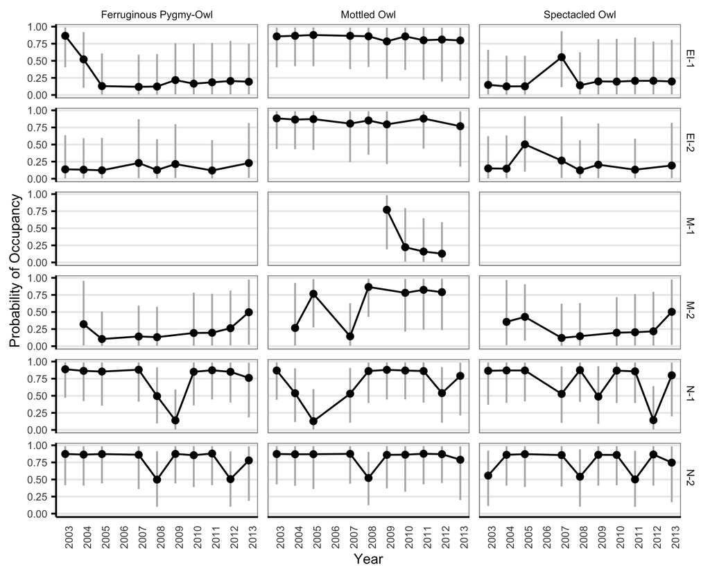

```r
ggplot(data = psi.post.all,
       aes(x = Year, y = Psi.median))+
  geom_linerange(aes(ymin = Psi.LL05, ymax = Psi.UL95), color = "#b5b5b5")+
  geom_line()+
  geom_point()+
  #facet_grid(code~Route)+
  facet_grid(Route~code)+
  theme_minimal()+
  xlab("Year")+
  ylab("Probability of Occupancy")+
  scale_x_continuous(breaks = 2003:2013, limits = c(2003,2013))+
  theme(axis.text.x = element_text(size=6, angle = 90),
        axis.text.y = element_text(size=6),
        axis.title = element_text(size=8),
        #axis.title.x = element_blank(),
        panel.border = element_rect(linetype = "solid", fill = NA, color = "#969696"),
        strip.text = element_text(size =6, margin = margin(0,0.1,0.1,0.1, "cm")),
        panel.grid.major.x = element_blank(),
        panel.grid.minor.x = element_blank(),
        axis.line.x.bottom = element_line(colour = "black"),
        axis.line.y.left = element_line(colour = "black"),
        panel.grid.minor.y = element_blank(),
        axis.ticks.y.left = element_line(colour = "black"))+
  annotate("segment", x=-Inf, xend=Inf, y=-Inf, yend=-Inf)+
  annotate("segment", x=-Inf, xend=-Inf, y=-Inf, yend=Inf)
```

Add in regression of median propability of occupancy versus time (logistic)

[output not shown]

```
## geom_path: Each group consists of only one observation. Do you need
## to adjust the group aesthetic?
```

```
## geom_path: Each group consists of only one observation. Do you need
## to adjust the group aesthetic?
```

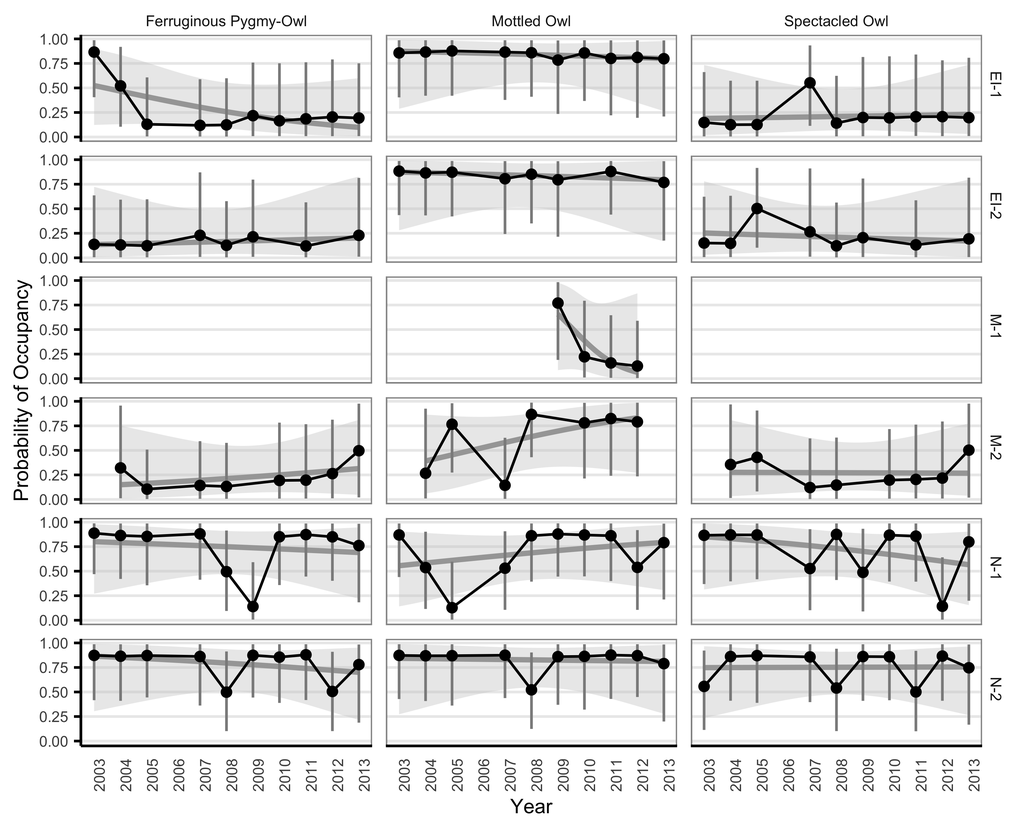

```r
ggplot(data = psi.post.all,
       aes(x = Year, y = Psi.median))+
  stat_smooth(method="glm", se=T, level = 0.90,
              method.args = list(family=binomial),
              color = "#a6a6a6", fill = "#cccccc") +
  geom_linerange(aes(ymin = Psi.LL05, ymax = Psi.UL95), color = "#8c8c8c")+
  geom_line()+
  geom_point()+
  facet_grid(Route~code)+
  theme_minimal()+
  xlab("Year")+
  ylab("Probability of Occupancy")+
  scale_x_continuous(breaks = 2003:2013, limits = c(2003,2013))+
  theme(axis.text.x = element_text(size=6, angle = 90),
        axis.text.y = element_text(size=6),
        axis.title = element_text(size=8),
        #axis.title.x = element_blank(),
        panel.border = element_rect(linetype = "solid", fill = NA, color = "#969696"),
        strip.text = element_text(size =6, margin = margin(0,0.1,0.1,0.1, "cm")),
        panel.grid.major.x = element_blank(),
        panel.grid.minor.x = element_blank(),
        axis.line.x.bottom = element_line(colour = "black"),
        axis.line.y.left = element_line(colour = "black"),
        panel.grid.minor.y = element_blank(),
        axis.ticks.y.left = element_line(colour = "black"))+
  annotate("segment", x=-Inf, xend=Inf, y=-Inf, yend=-Inf)+
  annotate("segment", x=-Inf, xend=-Inf, y=-Inf, yend=Inf)
```

## Regression output by species and route

Corresponds with trends on graph

**Ferpy**

EI-1

```r
summary(glm(Psi.median ~ Year,
            family = binomial,
            data = psi.post.ferpy[psi.post.ferpy$Route == "EI.1",]))
```

```
##
## Call:
## glm(formula = Psi.median ~ Year, family = binomial, data = psi.post.ferpy[psi.post.ferpy$Route ==
##     "EI.1", ])
##
## Deviance Residuals:
##      Min        1Q    Median        3Q       Max
## -0.61420  -0.25718   0.05349   0.20428   0.72619
##
## Coefficients:
##             Estimate Std. Error z value Pr(>|z|)
## (Intercept) 463.6112   483.9923   0.958    0.338
## Year         -0.2314     0.2411  -0.960    0.337
##
## (Dispersion parameter for binomial family taken to be 1)
##
##     Null deviance: 2.3933  on 9  degrees of freedom
## Residual deviance: 1.3691  on 8  degrees of freedom
## AIC: 10.856
##
## Number of Fisher Scoring iterations: 5
```

EI-2

```r
summary(glm(Psi.median ~ Year,
            family = binomial,
            data = psi.post.ferpy[psi.post.ferpy$Route == "EI.2",]))
```

```
##
## Call:
## glm(formula = Psi.median ~ Year, family = binomial, data = psi.post.ferpy[psi.post.ferpy$Route ==
##     "EI.2", ])
##
## Deviance Residuals:
##      Min        1Q    Median        3Q       Max
## -0.18177  -0.07910  -0.01055   0.07470   0.18182
##
## Coefficients:
##              Estimate Std. Error z value Pr(>|z|)
## (Intercept) -99.63735  588.36920  -0.169    0.866
## Year          0.04882    0.29303   0.167    0.868
##
## (Dispersion parameter for binomial family taken to be 1)
##
##     Null deviance: 0.126405  on 7  degrees of freedom
## Residual deviance: 0.098697  on 6  degrees of freedom
## AIC: 6.8703
##
## Number of Fisher Scoring iterations: 5
```

M-2

```r
summary(glm(Psi.median ~ Year,
            family = binomial,
            data = psi.post.ferpy[psi.post.ferpy$Route == "M.2",]))
```

```
##
## Call:
## glm(formula = Psi.median ~ Year, family = binomial, data = psi.post.ferpy[psi.post.ferpy$Route ==
##     "M.2", ])
##
## Deviance Residuals:
##      Min        1Q    Median        3Q       Max
## -0.20788  -0.17024  -0.13714   0.04557   0.42935
##
## Coefficients:
##              Estimate Std. Error z value Pr(>|z|)
## (Intercept) -214.7819   571.6876  -0.376    0.707
## Year           0.1063     0.2845   0.374    0.709
##
## (Dispersion parameter for binomial family taken to be 1)
##
##     Null deviance: 0.61560  on 7  degrees of freedom
## Residual deviance: 0.47082  on 6  degrees of freedom
## AIC: 8.2505
##
## Number of Fisher Scoring iterations: 4
```

N-1

```r
summary(glm(Psi.median ~ Year,
            family = binomial,
            data = psi.post.ferpy[psi.post.ferpy$Route == "N.1",]))
```

```
##
## Call:
## glm(formula = Psi.median ~ Year, family = binomial, data = psi.post.ferpy[psi.post.ferpy$Route ==
##     "N.1", ])
##
## Deviance Residuals:
##     Min       1Q   Median       3Q      Max
## -1.2580   0.1641   0.2108   0.3016   0.3780
##
## Coefficients:
##              Estimate Std. Error z value Pr(>|z|)
## (Intercept) 119.21560  456.18281   0.261    0.794
## Year         -0.05882    0.22713  -0.259    0.796
##
## (Dispersion parameter for binomial family taken to be 1)
##
##     Null deviance: 2.5373  on 9  degrees of freedom
## Residual deviance: 2.4693  on 8  degrees of freedom
## AIC: 14.161
##
## Number of Fisher Scoring iterations: 4
```

N-2

```r
summary(glm(Psi.median ~ Year,
            family = binomial,
            data = psi.post.ferpy[psi.post.ferpy$Route == "N.2",]))
```

```
##
## Call:
## glm(formula = Psi.median ~ Year, family = binomial, data = psi.post.ferpy[psi.post.ferpy$Route ==
##     "N.2", ])
##
## Deviance Residuals:
##      Min        1Q    Median        3Q       Max
## -0.65672   0.02592   0.11310   0.22181   0.34155
##
## Coefficients:
##             Estimate Std. Error z value Pr(>|z|)
## (Intercept) 203.9545   497.1211   0.410    0.682
## Year         -0.1009     0.2475  -0.408    0.683
##
## (Dispersion parameter for binomial family taken to be 1)
##
##     Null deviance: 1.10453  on 9  degrees of freedom
## Residual deviance: 0.93208  on 8  degrees of freedom
## AIC: 11.563
##
## Number of Fisher Scoring iterations: 4
```

**Mottled Owl**

EI-1

```r
summary(glm(Psi.median ~ Year,
            family = binomial,
            data = psi.post.mottd[psi.post.mottd$Route == "EI.1",]))
```

```
##
## Call:
## glm(formula = Psi.median ~ Year, family = binomial, data = psi.post.mottd[psi.post.mottd$Route ==
##     "EI.1", ])
##
## Deviance Residuals:
##       Min         1Q     Median         3Q        Max
## -0.126177  -0.032248   0.001137   0.048676   0.086387
##
## Coefficients:
##              Estimate Std. Error z value Pr(>|z|)
## (Intercept) 113.25563  539.63650   0.210    0.834
## Year         -0.05557    0.26866  -0.207    0.836
##
## (Dispersion parameter for binomial family taken to be 1)
##
##     Null deviance: 0.078406  on 9  degrees of freedom
## Residual deviance: 0.034965  on 8  degrees of freedom
## AIC: 7.5555
##
## Number of Fisher Scoring iterations: 5
```

EI-2

```r
summary(glm(Psi.median ~ Year,
            family = binomial,
            data = psi.post.mottd[psi.post.mottd$Route == "EI.2",]))
```

```
##
## Call:
## glm(formula = Psi.median ~ Year, family = binomial, data = psi.post.mottd[psi.post.mottd$Route ==
##     "EI.2", ])
##
## Deviance Residuals:
##      Min        1Q    Median        3Q       Max
## -0.10636  -0.07047   0.01141   0.03595   0.18182
##
## Coefficients:
##             Estimate Std. Error z value Pr(>|z|)
## (Intercept) 118.7040   594.6563   0.200    0.842
## Year         -0.0583     0.2962  -0.197    0.844
##
## (Dispersion parameter for binomial family taken to be 1)
##
##     Null deviance: 0.098896  on 7  degrees of freedom
## Residual deviance: 0.060166  on 6  degrees of freedom
## AIC: 6.7932
##
## Number of Fisher Scoring iterations: 5
```

M-1

```r
summary(glm(Psi.median ~ Year,
            family = binomial,
            data = psi.post.mottd[psi.post.mottd$Route == "M.1",]))
```

```
##
## Call:
## glm(formula = Psi.median ~ Year, family = binomial, data = psi.post.mottd[psi.post.mottd$Route ==
##     "M.1", ])
##
## Deviance Residuals:
##  psi[3,7]   psi[3,8]   psi[3,9]  psi[3,10]
##   0.24851   -0.35158   -0.03511    0.23018
##
## Coefficients:
##             Estimate Std. Error z value Pr(>|z|)
## (Intercept) 2222.146   2577.061   0.862    0.389
## Year          -1.106      1.282  -0.862    0.388
##
## (Dispersion parameter for binomial family taken to be 1)
##
##     Null deviance: 1.23343  on 3  degrees of freedom
## Residual deviance: 0.23958  on 2  degrees of freedom
## AIC: 6.335
##
## Number of Fisher Scoring iterations: 5
```

M-2

```r
summary(glm(Psi.median ~ Year,
            family = binomial,
            data = psi.post.mottd[psi.post.mottd$Route == "M.2",]))
```

```
##
## Call:
## glm(formula = Psi.median ~ Year, family = binomial, data = psi.post.mottd[psi.post.mottd$Route ==
##     "M.2", ])
##
## Deviance Residuals:
##  psi[4,2]   psi[4,3]   psi[4,5]   psi[4,6]   psi[4,8]   psi[4,9]
##  -0.26353    0.63643   -0.90576    0.50948    0.07697    0.07993
## psi[4,10]
##  -0.10572
##
## Coefficients:
##              Estimate Std. Error z value Pr(>|z|)
## (Intercept) -509.8451   617.0286  -0.826    0.409
## Year           0.2542     0.3073   0.827    0.408
##
## (Dispersion parameter for binomial family taken to be 1)
##
##     Null deviance: 2.3304  on 6  degrees of freedom
## Residual deviance: 1.5780  on 5  degrees of freedom
## AIC: 10.617
##
## Number of Fisher Scoring iterations: 4
```

N-1

```r
summary(glm(Psi.median ~ Year,
            family = binomial,
            data = psi.post.mottd[psi.post.mottd$Route == "N.1",]))
```

```
##
## Call:
## glm(formula = Psi.median ~ Year, family = binomial, data = psi.post.mottd[psi.post.mottd$Route ==
##     "N.1", ])
##
## Deviance Residuals:
##     Min       1Q   Median       3Q      Max
## -1.0027  -0.2276   0.1289   0.3851   0.6772
##
## Coefficients:
##              Estimate Std. Error z value Pr(>|z|)
## (Intercept) -224.6842   429.3877  -0.523    0.601
## Year           0.1123     0.2139   0.525    0.600
##
## (Dispersion parameter for binomial family taken to be 1)
##
##     Null deviance: 2.6048  on 9  degrees of freedom
## Residual deviance: 2.3228  on 8  degrees of freedom
## AIC: 12.556
##
## Number of Fisher Scoring iterations: 4
```

N-2

```r
summary(glm(Psi.median ~ Year,
            family = binomial,
            data = psi.post.mottd[psi.post.mottd$Route == "N.2",]))
```

```
##
## Call:
## glm(formula = Psi.median ~ Year, family = binomial, data = psi.post.mottd[psi.post.mottd$Route ==
##     "N.2", ])
##
## Deviance Residuals:
##      Min        1Q    Median        3Q       Max
## -0.70285   0.08202   0.09442   0.11946   0.15895
##
## Coefficients:
##              Estimate Std. Error z value Pr(>|z|)
## (Intercept)  46.43538  519.15996   0.089    0.929
## Year         -0.02234    0.25850  -0.086    0.931
##
## (Dispersion parameter for binomial family taken to be 1)
##
##     Null deviance: 0.61155  on 9  degrees of freedom
## Residual deviance: 0.60405  on 8  degrees of freedom
## AIC: 7.8052
##
## Number of Fisher Scoring iterations: 4
```

**Spectacled Owl**

EI-1

```r
summary(glm(Psi.median ~ Year,
            family = binomial,
            data = psi.post.specd[psi.post.specd$Route == "EI.1",]))
```

```
##
## Call:
## glm(formula = Psi.median ~ Year, family = binomial, data = psi.post.specd[psi.post.specd$Route ==
##     "EI.1", ])
##
## Deviance Residuals:
##      Min        1Q    Median        3Q       Max
## -0.18622  -0.15675  -0.06618  -0.03813   0.76327
##
## Coefficients:
##              Estimate Std. Error z value Pr(>|z|)
## (Intercept) -50.97307  482.51736  -0.106    0.916
## Year          0.02472    0.24026   0.103    0.918
##
## (Dispersion parameter for binomial family taken to be 1)
##
##     Null deviance: 0.71563  on 9  degrees of freedom
## Residual deviance: 0.70500  on 8  degrees of freedom
## AIC: 11.429
##
## Number of Fisher Scoring iterations: 4
```

EI-2

```r
summary(glm(Psi.median ~ Year,
            family = binomial,
            data = psi.post.specd[psi.post.specd$Route == "EI.2",]))
```

```
##
## Call:
## glm(formula = Psi.median ~ Year, family = binomial, data = psi.post.specd[psi.post.specd$Route ==
##     "EI.2", ])
##
## Deviance Residuals:
##      Min        1Q    Median        3Q       Max
## -0.24911  -0.23021  -0.06764   0.07040   0.57918
##
## Coefficients:
##              Estimate Std. Error z value Pr(>|z|)
## (Intercept)  97.71678  542.42313   0.180    0.857
## Year         -0.04933    0.27024  -0.183    0.855
##
## (Dispersion parameter for binomial family taken to be 1)
##
##     Null deviance: 0.57664  on 7  degrees of freedom
## Residual deviance: 0.54288  on 6  degrees of freedom
## AIC: 10.238
##
## Number of Fisher Scoring iterations: 4
```

M-2

```r
summary(glm(Psi.median ~ Year,
            family = binomial,
            data = psi.post.specd[psi.post.specd$Route == "M.2",]))
```

```
##
## Call:
## glm(formula = Psi.median ~ Year, family = binomial, data = psi.post.specd[psi.post.specd$Route ==
##     "M.2", ])
##
## Deviance Residuals:
##     Min       1Q   Median       3Q      Max
## -0.3705  -0.2032  -0.1348   0.2125   0.4982
##
## Coefficients:
##               Estimate Std. Error z value Pr(>|z|)
## (Intercept)   8.827443 519.499306   0.017    0.986
## Year         -0.004886   0.258621  -0.019    0.985
##
## (Dispersion parameter for binomial family taken to be 1)
##
##     Null deviance: 0.68092  on 7  degrees of freedom
## Residual deviance: 0.68056  on 6  degrees of freedom
## AIC: 11.085
##
## Number of Fisher Scoring iterations: 4
```

N-1

```r
summary(glm(Psi.median ~ Year,
            family = binomial,
            data = psi.post.specd[psi.post.specd$Route == "N.1",]))
```

```
##
## Call:
## glm(formula = Psi.median ~ Year, family = binomial, data = psi.post.specd[psi.post.specd$Route ==
##     "N.1", ])
##
## Deviance Residuals:
##     Min       1Q   Median       3Q      Max
## -0.9505  -0.3252   0.1332   0.4278   0.4925
##
## Coefficients:
##             Estimate Std. Error z value Pr(>|z|)
## (Intercept) 298.2554   465.1781   0.641    0.521
## Year         -0.1480     0.2316  -0.639    0.523
##
## (Dispersion parameter for binomial family taken to be 1)
##
##     Null deviance: 2.6463  on 9  degrees of freedom
## Residual deviance: 2.2101  on 8  degrees of freedom
## AIC: 13.391
##
## Number of Fisher Scoring iterations: 4
```

N-2

```r
summary(glm(Psi.median ~ Year,
            family = binomial,
            data = psi.post.specd[psi.post.specd$Route == "N.2",]))
```

```
##
## Call:
## glm(formula = Psi.median ~ Year, family = binomial, data = psi.post.specd[psi.post.specd$Route ==
##     "N.2", ])
##
## Deviance Residuals:
##     Min       1Q   Median       3Q      Max
## -0.5450  -0.3162   0.2609   0.2734   0.2994
##
## Coefficients:
##               Estimate Std. Error z value Pr(>|z|)
## (Intercept)  -6.714928 452.356179  -0.015    0.988
## Year          0.003896   0.225257   0.017    0.986
##
## (Dispersion parameter for binomial family taken to be 1)
##
##     Null deviance: 1.1287  on 9  degrees of freedom
## Residual deviance: 1.1284  on 8  degrees of freedom
## AIC: 9.6982
##
## Number of Fisher Scoring iterations: 4
```

## p = Probability of detection

Merge data

```r
p.det.post.richness$Species <- "All Species"
```

```r
p.det.post <- rbind(p.det.post.ferpy, p.det.post.mottd,
                    p.det.post.specd,p.det.post.richness)
table(p.det.post$Broadcast)
```

```
##
##         Pre-broadcast           Mottled Owl   Pacific Screech-Owl
##                     4                     4                     4
##           Crested Owl   Black-and-white Owl        Spectacled Owl
##                     4                     4                     4
## Whiskered Screech-Owl           Fulvous Owl           Stygian Owl
##                     4                     4                     4
##      Great Horned Owl
##                     4
```

```r
table(p.det.post$Species)
```

```
##
## All Species       FerPy       Mottd       Specd
##          10          10          10          10
```

```r
p.det.post$Species[p.det.post$Species == "FerPy"] <- "Ferruginous Pygmy-Owl"
p.det.post$Species[p.det.post$Species == "Mottd"] <- "Mottled Owl"
p.det.post$Species[p.det.post$Species == "Specd"] <- "Spectacled Owl"
```

Probability of detection was a function of what broadcast species was used, with a constant probability of detection for all pre-broadcast time periods.

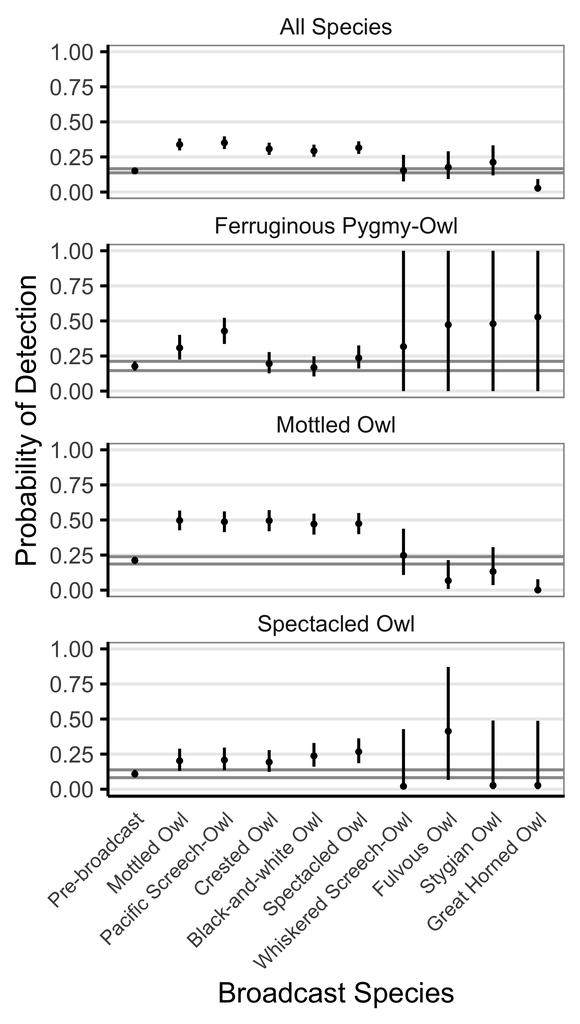

```r
ggplot(data = p.det.post, aes(y = median.plogis, x = Broadcast, group = Species))+
  scale_fill_manual(values = c("darkgrey", "#7fc97f", "#beaed4", "#fdc086"))+
  geom_hline(data = p.det.post[p.det.post$broadcast.param == "beta.prebroad",],
             aes(yintercept = LL05.plogis), color = "#999999")+
  geom_hline(data = p.det.post[p.det.post$broadcast.param == "beta.prebroad",],
             aes(yintercept = UL95.plogis), color = "#999999")+
  geom_point(size = 0.5)+
  geom_linerange(aes(ymin = LL05.plogis, ymax = UL95.plogis),
                 position = position_dodge(0.9))+
  facet_wrap(~Species, nrow = 4)+
  ylab("Probability of Detection")+
  xlab("Broadcast Species")+
  theme_minimal()+
  theme(axis.text.x = element_text(angle = 45, hjust = 1, size = 7),
        legend.position = "none",
        axis.text.y = element_text(size=8),
        axis.title = element_text(size=10),
        panel.border = element_rect(linetype = "solid", fill = NA, color = "#969696"),
        strip.text = element_text(size =8, margin = margin(0,0.1,0.1,0.1, "cm")),
        panel.grid.major.x = element_blank(),
        panel.grid.minor.x = element_blank(),
        axis.line.x.bottom = element_line(colour = "black"),
        axis.line.y.left = element_line(colour = "black"),
        panel.grid.minor.y = element_blank(),
        axis.ticks.y.left = element_line(colour = "black"))+
  annotate("segment", x=-Inf, xend=Inf, y=-Inf, yend=-Inf)+
  annotate("segment", x=-Inf, xend=-Inf, y=-Inf, yend=Inf)
```

## Richness by Route and Year

Last minute fix for Route names

```r
table(richness.RtYr.post$Route)
```

```
##
## EI1 EI2  M1  M2  N1  N2
##  10   8   4   7  10  10
```

```r
richness.RtYr.post$Route <- ifelse(richness.RtYr.post$Route == "EI1", "EI-1",
                           ifelse(richness.RtYr.post$Route == "EI2", "EI-2",
                                  ifelse(richness.RtYr.post$Route == "M1", "M-1",
                                         ifelse(richness.RtYr.post$Route == "M2", "M-2",
                                                ifelse(richness.RtYr.post$Route == "N1", "N-1",
                                                       "N-2")))))
table(richness.RtYr.post$Route)
```

```
##
## EI-1 EI-2  M-1  M-2  N-1  N-2
##   10    8    4    7   10   10
```

All 6 routes

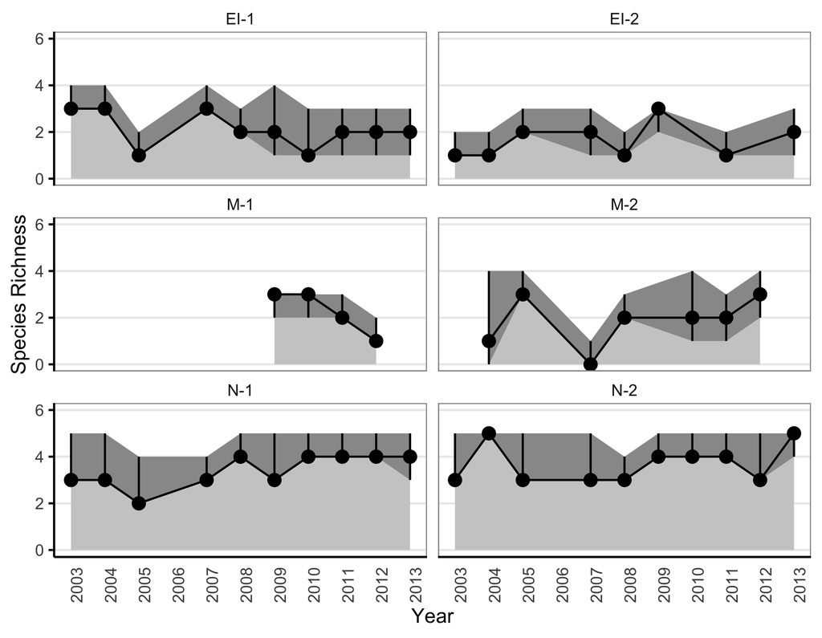

```r
ggplot(data = richness.RtYr.post,
       aes(x = Year, y = Richness.median, group = Route))+
  # tried vertical bar as shown below, commented out, per associate editor's suggestion
  #geom_col(aes(y = richness.detected), fill = "#cccccc")+
  geom_ribbon(aes(ymax = richness.detected, ymin = 0), fill = "#cccccc")+
  geom_ribbon(aes(ymin = Richness.median,
                  ymax = Richness.UL95), fill = "#999999")+
  geom_ribbon(aes(ymin = richness.detected,
                  ymax = Richness.median), fill = "#999999")+
  geom_pointrange(aes(ymin = Richness.LL05, ymax = Richness.UL95))+
  geom_line()+
  facet_wrap(~Route, nrow = 3)+
  theme_minimal()+
  xlab("Year")+
  ylab("Species Richness")+
  scale_x_continuous(breaks = 2003:2013)+
  scale_y_continuous(breaks = seq(0,14,by=2), limits = c(0,6))+
  theme(axis.text.x = element_text(size=8, angle = 90),
        axis.text.y = element_text(size=8),
        axis.title = element_text(size=10),
        panel.border = element_rect(linetype = "solid",
                                    fill = NA, color = "#969696"),
        strip.text = element_text(size =8, margin = margin(0,0.1,0.1,0.1, "cm")),
        panel.grid.major.x = element_blank(),
        panel.grid.minor.x = element_blank(),
        axis.line.x.bottom = element_line(colour = "black"),
        axis.line.y.left = element_line(colour = "black"),
        panel.grid.minor.y = element_blank(),
        axis.ticks.y.left = element_line(colour = "black"))+
  annotate("segment", x=-Inf, xend=Inf, y=-Inf, yend=-Inf)+
  annotate("segment", x=-Inf, xend=-Inf, y=-Inf, yend=Inf)
```

## Location map

Extract country data

```r
ElSalvador <- getData("GADM", country = "SV", level = 0)
Guatemala <- getData("GADM", country = "GT", level = 0)
Honduras <- getData("GADM", country = "HN", level = 0)

# Process into df for ggplot
ElSalvador <- fortify(ElSalvador)
Guatemala <- fortify(Guatemala)
Honduras <- fortify(Honduras)
# Range for mapping
range(ElSalvador$long)
```

```
## [1] -90.12486 -87.68375
```

```r
range(ElSalvador$lat)
```

```
## [1] 13.15264 14.45055
```

```r
#ElSalvador$y <- ElSalvador$lat
#ElSalvador$x <- ElSalvador$long
```

Map of protected areas

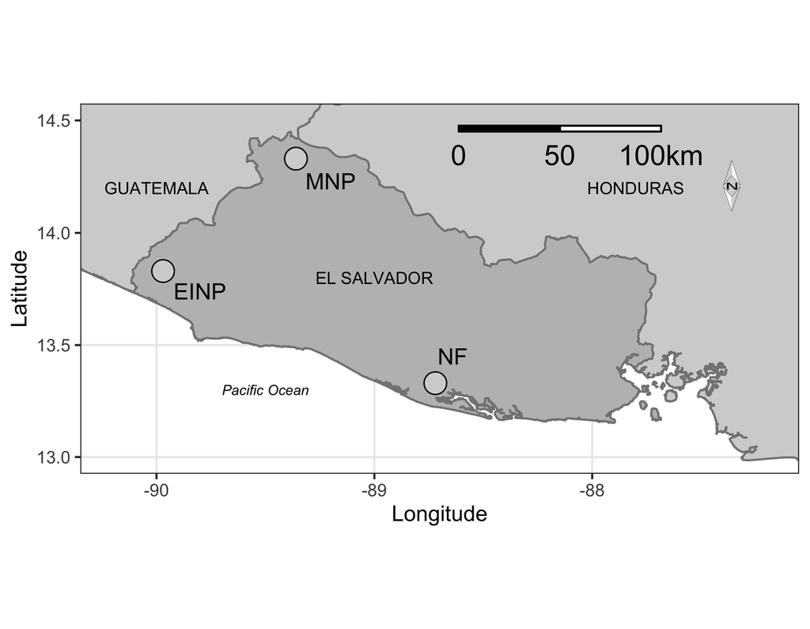

```r
p <- ggplot(data = ElSalvador, aes(x = long, y = lat, group = group))+
  geom_polygon(fill = "grey", color = "#848484")+
  geom_polygon(data = Honduras, aes(x = long, y = lat, group = group),
               fill = "lightgrey", color = "#848484")+
  geom_polygon(data = Guatemala, aes(x = long, y = lat, group = group),
               fill = "lightgrey", color = "#848484")+
  coord_map(xlim = c(-90.2, -87.2), ylim = c(13.0, 14.5))+
  # El Imposible
  annotate(geom = "text", y = 13.74, x = -89.8, label = "EINP", size = 4)+
  annotate(geom = "point", y = 13.83, x = -89.97, size = 5, shape = 21, fill = "lightgrey")+
  # Montecristo
  annotate(geom = "text", y = 14.23, x = -89.2, label = "MNP", size = 4)+
  annotate(geom = "point", y = 14.33, x = -89.36, size = 5, shape = 21, fill = "lightgrey")+
  # Nancuchiname
  annotate(geom = "text", y = 13.45, x = -88.64, label = "NF", size = 4)+
  annotate(geom = "point", y = 13.33, x = -88.72, size = 5, shape = 21, fill = "lightgrey")+
  # Country & Ocean names
  annotate(geom = "text", y = 13.8, x = -89.0, label = "EL SALVADOR", size = 3)+
  annotate(geom = "text", y = 14.2, x = -90.0, label = "GUATEMALA", size = 3)+
  annotate(geom = "text", y = 14.2, x = -87.8, label = "HONDURAS", size = 3)+
  annotate(geom = "text", y = 13.3, x = -89.5, label = "Pacific Ocean", size = 2.5,
           fontface = "italic")+
  ylab("Latitude")+
  xlab("Longitude")+
  ggsn::scalebar(ElSalvador,
                 transform = TRUE, dist_unit = "km",
                 dist = 50, location = "topright",
                 border.size = 0.5,
                 st.dist = 0.08,
                 st.bottom = T)+
  theme_bw()
ggsn::north2(p, x = 0.9, y = 0.7, symbol = 5)
```

### Footer

This document was “spun” with:

ezknitr::ezspin(file = “programs/g_graphing_results_global.R”, out_dir = “output”, fig_dir = “figures”, keep_md = F)